# Dynamic Default Rates Repuroduction

Naoya Hieda

2017年05月01日

# 3.Emrical Implementation

## 大雑把な内容

2章にて変換されたデフォルト率$\Phi(q)^{-1}$が従うモデルを示した。  
自己相関ありとなしの場合で、6つのローンカテゴリーのデータをモデルに当てはめる。  
カテゴリーはそれぞれ、米国の不動産、クレジットカード、それ以外のローン、リース、工業、農業

[Federal Reserve Board charge-off-data](https://www.federalreserve.gov/releases/chargeoff/chgallsa.htm?raw=true)

データの読み込みと必要なデータの抜き出し  
年率換算されているので四半期毎の値に戻して、LGDの値で除算  
各期の純粋なデフォルト率のデータになっているはず

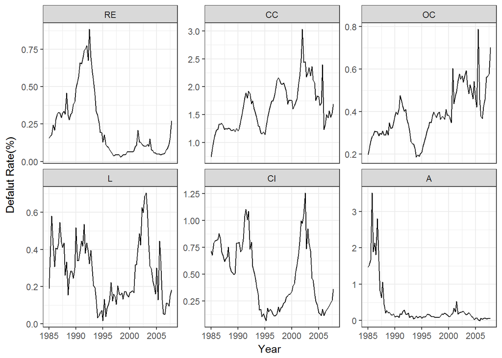

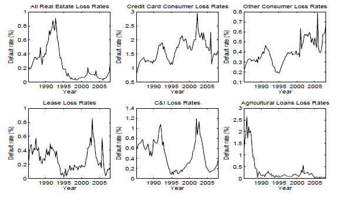

```r
charge_off_data <- read.table('data/N_FRB_CHGDEL.csv',encoding='utf-8',sep=',')


#ネット上とcsvで列の順番が違うので注意
repro_data <- charge_off_data[7:98,c(5,9,10,8,4,3)] %>% apply(2,as.numeric)
colnames(repro_data) <- c('RE','CC','OC','L','CI','A')
#各シリーズのLGD(Loss given defalut を除算) データが年率に変換されているのでそこも修正
LGD <- c(0.35,0.65,0.65,0.45,0.45,0.45)
#co_data <- t((1+repro_data)^(1/4)-1)/LGD
co_data <- t(1-((100-repro_data)/100)^(1/4))/LGD*100

co_data <- ts(t(co_data), frequency = 4, start = c(1985,1))
#ちょっと強引に四半期時系列生成
date <- time(co_data) %>% c() %>% as.numeric()
ggplot(co_data %>% melt,aes(x=date[Var1],y=value))+geom_line()+
  facet_wrap(~Var2,scales="free_y",ncol=3)+
  xlab('Year')+ylab('Defalut Rate(%)')
```

```r
colMeans(co_data)
```

```
##        RE        CC        OC         L        CI         A
## 0.2312658 1.6500467 0.3858258 0.2754489 0.4900557 0.3568671
```

```r
sqrt(colMeans(co_data^2)-colMeans(co_data)^2)
```

```
##        RE        CC        OC         L        CI         A
## 0.2139676 0.4170870 0.1191452 0.1629701 0.3074676 0.6120198
```

|  | RE | CC | OC | L | CI | A |
| --- | --- | --- | --- | --- | --- | --- |
| Loss rete series mean(%) | 0.25 | 1.63 | 0.39 | 0.27 | 0.47 | 0.36 |
| Loss rate std dev(%) | 0.23 | 0.39 | 0.12 | 0.16 | 0.29 | 0.56 |

全体的に、論文のものとはちょっとだけずれてしまう  
元データが、論文のころは四半期でそのまま表示されていたが、現在は各期の値が年率換算されているため。

CrecitCardのデフォルト率の平均が最も高いが、ボラティリティは他のカテゴリーとあまり変わらない  
CrecitCardがほかのカテゴリーよりもリスクが高いことが伺える。  
ただし、VaRやデフォルト率や資産相関など複雑な計算式に依存している資本は、Volatilityから単純に計算できるものではない。

なぜか2005年4月Aのデフォルト率がマイナス扱いなので、1e-10にしておく  
この後のAに関する計算結果はずっとおかしいけどしょうがない

```r
co_data[co_data<0] <- 1e-10
```

元のデータを小数点表示に直してから 単純に標準正規分布cdfの逆数$\Phi^{-1}$で変換したもの

```r
pnorm_co_data <- qnorm(co_data/100)
```

regression on constant が lm(r ~ 0)で実装できるようなので

```r
Regression_on_constant <- {}
for(i in 1:6){
tmp <- data.frame(y = pnorm_co_data[,i])
fit <- lm(y ~ 0,data=tmp)
Regression_on_constant <- c(Regression_on_constant,list(summary(fit)))
}
```

回帰誤差ボラティリティ(残差の標準偏差)

```r
Regression_residual_volatility <- sapply(Regression_on_constant,function(x)sqrt(var(x$residuals)))
```

beta=0で(24)(25)が成り立っていると考えればいい?
$$\tilde{\theta}_t=\sqrt{\beta}\tilde{\theta}_{t-1}+\frac{(1-\sqrt{\beta})}{\sqrt{1-\rho}}\Phi^{-1}(q)-\frac{\sqrt{\rho}\sqrt{1-\beta}}{\sqrt{1-\rho}}\eta_t\\
\tilde{\theta_t} = \Phi^{-1}(\theta_t)\sim N(\sqrt{\beta}\tilde{\theta}_{t-1}+\frac{(1-\sqrt{\beta})}{\sqrt{1-\rho}}\Phi^{-1}(q),\frac{\rho(1-\beta)}{1-\rho})\\
\\\\
\beta=0のとき,\\
\tilde{\theta}=\frac{1}{\sqrt{1-\rho}}\Phi^{-1}(q)-\frac{\sqrt{\rho}}{\sqrt{1-\rho}}\eta_t\\
\tilde{\theta} = N(\frac{1}{\sqrt{1-\rho}}\Phi^{-1}(q),\frac{\rho}{1-\rho})$$

最適化 分散から相関係数$\rho$を推定して、平均から無条件デフォルト確率qを推定する
それぞれの目的関数は 相関係数
$$f(\rho)=\sqrt{(\sigma^2-\frac{\rho}{1-\rho})^2}$$
無条件デフォルト確率
$$f(q)=\sqrt{(\frac{\Phi(q)^{-1}}{\sqrt{1-\rho}}-\mu)^2}$$
相関係数は準ニュートン法
無条件デフォルト確率はBrent法

```r
factor_correlation <- c()
std_error_rho <- c()
for(sd_2 in Regression_residual_volatility^2){
  f <- function (rho) sqrt((sd_2 - rho/(1-rho))^2)
  opt_result <- optim(par=0,fn=f,method = 'BFGS',lower=0,upper=1-1e-10,hessian = TRUE)
  factor_correlation <- c(factor_correlation,opt_result$par)
  std_error_rho <- c(std_error_rho,sqrt(solve(opt_result$hessian)))
}
un_defalut_rate <- c()
std_error_q <- c()
for(i in c(1:6)){
  f <- function (q) sqrt((qnorm(q)/sqrt(1 - factor_correlation[i]) - colMeans(pnorm_co_data)[i])^2)
  opt_result <- optim(par=0.1,fn=f,method = 'Brent',lower=0,upper=1-1e-10,hessian = TRUE)
  un_defalut_rate <- c(un_defalut_rate,opt_result$par)
  std_error_q <- c(std_error_q,sqrt(solve(opt_result$hessian)))
}
```

論文と同じ表形式で表示

```r
table_1 <- t(data.frame(Regression_residual_volatility*100,factor_correlation*100,std_error_rho*100,un_defalut_rate*100,std_error_q*100))
colnames(table_1) <-  c('RE','CC','OC','L','CI','A')
rownames(table_1) <- c('Regression_residual_volatility(%)','factor_correlation(%)','std_error_rho(%)','un_defalut_rate(%)','std_error_q(%)')
table_1
```

```
##                                           RE         CC         OC
## Regression_residual_volatility(%) 29.4740245 10.2164384 10.4461122
## factor_correlation(%)              7.9927209  1.0328785  1.0793326
## std_error_rho(%)                   2.9103096  3.1303595  3.1289306
## un_defalut_rate(%)                 0.2306016  1.6506587  0.3860929
## std_error_q(%)                     0.2191157  0.6382349  0.3233884
##                                            L         CI          A
## Regression_residual_volatility(%) 22.9442412 25.1719746 55.2085793
## factor_correlation(%)              5.0010027  5.9586152 23.3596964
## std_error_rho(%)                   3.0048922  2.9746339  2.4243619
## un_defalut_rate(%)                 0.2831405  0.4988062  0.4990403
## std_error_q(%)                     0.2645672  0.3649684  0.3468499
```

| Parameter Estimates with No Autocorrelation(論文内) |  |  |  |  |  |  |
| --- | --- | --- | --- | --- | --- | --- |
| Regression residual volatility (%) | 30.12 | 9.62 | 10.17 | 21.74 | 24.39 | 40.37 |
| Factor correlation ρ (%) | 8.32 | 0.92 | 1.02 | 4.51 | 5.62 | 14.01 |
| Std error ρ (%) | 1.13 | 0.13 | 0.15 | 0.64 | 0.79 | 1.79 |
| Unconditional default probability q (%) | 0.25 | 1.63 | 0.39 | 0.28 | 0.48 | 0.35 |
| Std error q (%) | 0.07 | 0.09 | 0.03 | 0.05 | 0.09 | 0.12 |

cdfで変換した後のデフォルト率について Regression residual volatility(平均との差分の分散)でみると、CreditCardが一番低くなった。  
また、カテゴリー内の相関係数にあたる$\rho$もCreditCardが一番低くなった。

$X_t$とInovationsを計算しておく これが何なのかは、後で詳しく書く

```r
X_t_noauto <- t((qnorm(un_defalut_rate)-sqrt(1-factor_correlation)*t(pnorm_co_data))/sqrt(factor_correlation))
```

自己相関を持つ場合を考えるので(25)の$\beta\neq0$で考える  
一期前の値に対して線形回帰

```r
Regression_AR <- {}
for(i in 1:6){
tmp <- data.frame(y = pnorm_co_data[2:92,i],x = pnorm_co_data[1:91,i])
fit <- lm(y ~ x ,data=tmp)
Regression_AR <- c(Regression_AR,list(summary(fit)))
}
```

回帰誤差ボラティリティ(残差の標準偏差)は先程と同じように取り出せる
$\beta$は回帰の係数
それぞれの目的関数は 相関係数
$$f(\rho)=\sqrt{(\sigma_{AR(1)}^2-\frac{\rho(1-\beta)}{1-\rho})^2}$$
無条件デフォルト確率
$$f(q)=\sum_{t=1}^{T-1}\log (\phi({x_{t+1}-\beta x_t-\frac{1-\beta}{\sqrt{1-\rho}}\Phi(q)^{-1}}))$$

```r
Regression_residual_volatility <- sapply(Regression_AR,function(x)sqrt(var(x$residuals)))
beta_ <- sapply(Regression_AR,function(x) x$coefficients['x','Estimate']^2)
beta_error <- sapply(Regression_AR,function(x) x$coefficients['x','Std. Error'])
factor_correlation <- c()
std_error_rho <- c()
for(i in 1:6){
  f <- function (rho) sqrt((Regression_residual_volatility[i]^2 - rho*(1-beta_[i])/(1-rho))^2)
  optim_result <- optim(par = 0,method = 'BFGS',f,lower = 0, upper =1-1e-10,hessian = TRUE)
  factor_correlation <- c(factor_correlation,optim_result$par)
  std_error_rho <- c(std_error_rho,sqrt(solve(optim_result$hessian)))
}
un_defalut_rate <- c()
std_error_q <- c()
for(i in c(1:6)){
  f <- function(q)
    -sum(log(dnorm((
      pnorm_co_data[2:92,i]-
        sqrt(beta_[i])*pnorm_co_data[1:91,i]-
        ((1-sqrt(beta_[i]))/sqrt(1-factor_correlation[i]))*qnorm(q))
      )))
  optim_result <- optim(par = 0,method = 'Brent',f,lower = 0, upper =1-1e-10,hessian = TRUE)
  un_defalut_rate <- c(un_defalut_rate,optim_result$par)
  std_error_q <- c(std_error_q,sqrt(solve(optim_result$hessian)))
}

table_2 <- t(data.frame(Regression_residual_volatility*100,factor_correlation*100,std_error_rho*100,un_defalut_rate*100,std_error_q*100,beta_*100,beta_error*100))
colnames(table_2) <-  c('RE','CC','OC','L','CI','A')
rownames(table_2) <- c('Regression_residual_volatility(%)','factor_correlation(%)','std_error_rho(%)','un_defalut_rate(%)','std_error_q(%)','beta(%)','std_error_beta(%)')
table_2
```

```
##                                           RE         CC         OC
## Regression_residual_volatility(%)  6.7838602  4.1815823  4.6631736
## factor_correlation(%)              8.6285471  0.6712246  1.0759320
## std_error_rho(%)                  13.0923577  6.1768594  6.9982686
## un_defalut_rate(%)                 0.2968581  1.7381772  0.4367584
## std_error_q(%)                     2.9521104  3.2135268  1.1592539
## beta(%)                           95.1267284 74.1282998 80.0087800
## std_error_beta(%)                  2.4309735  4.3156140  4.8281455
##                                            L         CI          A
## Regression_residual_volatility(%) 14.1759527  7.5871879 48.2333080
## factor_correlation(%)              5.0523838  5.5885227 23.0788733
## std_error_rho(%)                   4.8871552  9.5762178  2.7632768
## un_defalut_rate(%)                 0.2839976  0.4245542  0.4688667
## std_error_q(%)                     0.3287969  2.3230608  0.2212784
## beta(%)                           62.2355900 90.2751916 22.4606867
## std_error_beta(%)                  6.5160896  3.1776070  9.2266881
```

| Parameter Estimates with Autocorrelation |  |  |  |  |  |  |
| --- | --- | --- | --- | --- | --- | --- |
| Regression residual volatility (%) | 8.27 | 4.25 | 4.61 | 12.19 | 6.95 | 25.77 |
| Factor correlation ρ (%) | 8.67 | 0.64 | 1.05 | 4.66 | 5.3 | 13.49 |
| Std error ρ (%) | 6.22 | 0.2 | 0.48 | 1.59 | 3.41 | 3.3 |
| Unconditional default probability q (%) | 0.27 | 1.69 | 0.44 | 0.27 | 0.41 | 0.3 |
| Std error q (%) | 0.21 | 0.13 | 0.07 | 0.06 | 0.2 | 0.1 |
| AR(1) parameter β (%) | 92.8 | 71.84 | 79.97 | 69.62 | 91.37 | 57.4 |
| Std error β (%) | 5.55 | 7.85 | 8.67 | 9.86 | 5.71 | 10.22 |

自己相関がありのモデルを考えると、モデルに対するRegression residual volatility(モデルで計算される値と実測値の差分)が 実質減らすことになるので、全体的に値が小さくなる。  
にも拘わらず、相関係数の$rho$は、損失率の変動性を反映しているので先ほどとあまり変わらない

# 4 Factors and Correlations

## 4.1 Specification Tests

$\eta_t$のプロット 式に従って計算

式(33)を変換したものと、と式(34)からショックの値である$\eta_t$を計算
$$\tilde{\theta_t} = \frac{\Phi(q)^{-1} - \sqrt{\rho}X_t}{\sqrt{1-\rho}} から\\
X_t = \frac{\Phi(q)^{-1}-\sqrt{1-\rho}\tilde{\theta_t}}{\sqrt{\rho}} \\
\eta_t = \frac{X_t-\sqrt{\beta}X_{t-1}}{\sqrt{1-\beta}}$$

自己相関モデルが正しければ、一時遅れはデータから全ての時間依存性が除去されていて、ショックはホワイトノイズに従うべき。  
LeaseとAgriculturalとにショックのクラスタリングがある  
クレジットカードは高次の自己相関がある可能性がある

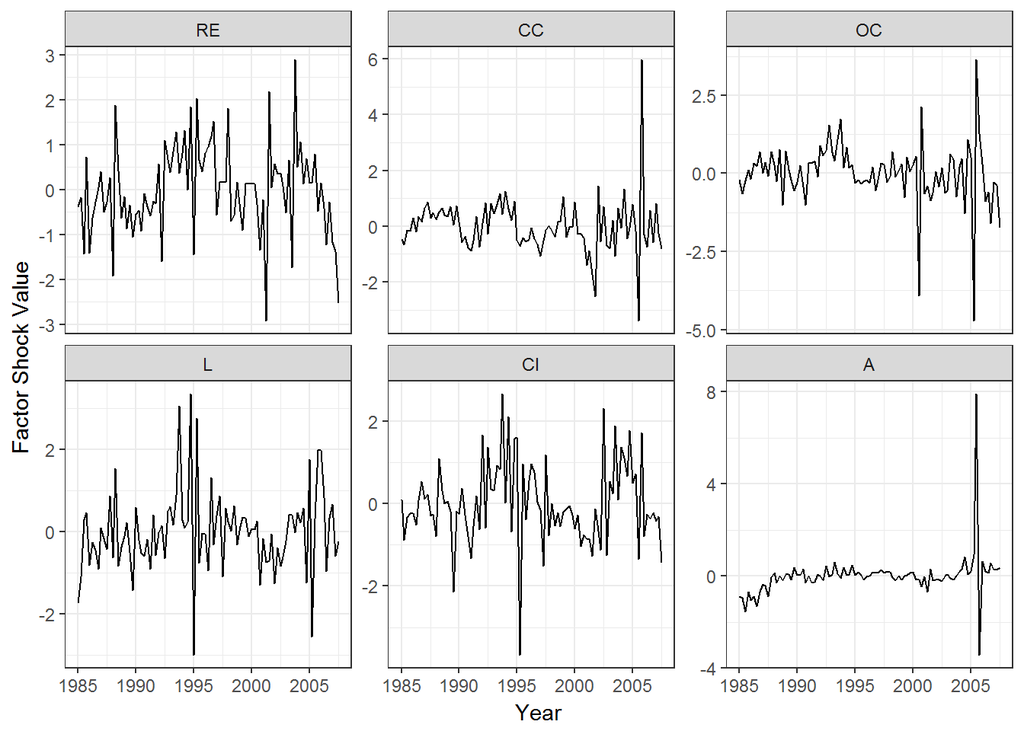

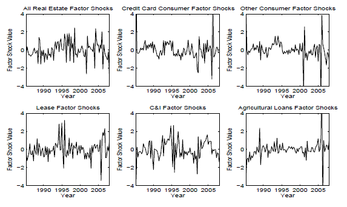

```r
X_t_auto<- t((qnorm(un_defalut_rate)-sqrt(1-factor_correlation)*t(pnorm_co_data))/sqrt(factor_correlation))
Inovations <- t((t(X_t_auto[2:92,])-sqrt(beta_)*t(X_t_auto[1:91,]))/sqrt(1-beta_))

data.frame(dt=date[-length(date)],Inovations) %>% melt(id='dt') %>% ggplot(aes(x=dt,y=value)) + geom_line() + facet_wrap(~variable,ncol=3,scales = 'free_y') + xlab('Year') + ylab('Factor Shock Value')
```

Durbin-Watoson-Testを用いて、回帰の残差から自己相関を検定する。 [Durbin-Watoson-Test](http://business.nikkeibp.co.jp/atclbdt/15/recipe/121100041/?ST=print) いずれの場合も95%の信頼区間に残差が存在することから独立であると言える。

Jarque-Bera-Testを用いて、歪度と尖度が正規性の値から統計的に有意に異なるか検定する。モンテカルロ計算らしいがこっちは明らかに表と値が違う。 [Jarque-Bera-Test](http://bio-info.biz/tips/r_jarque-bera_test.html) サンプルの歪度と尖度が正規性の値から有為に異なるかで正規分布かを検定する。信頼水準は5.99

```r
DW_test <- sapply(Regression_AR,function(x) durbinWatsonTest(x$residuals))
DW_test
```

```
## [1] 2.023159 2.263618 2.398341 2.422979 2.119346 2.277545
```

```r
JB_test <- sapply(Regression_AR,function(x) ajb.norm.test(x$residuals,nrepl = 1000)['statistic'])
t(JB_test)
```

```
##      statistic statistic statistic statistic statistic statistic
## [1,] 2.904044  874.4995  308.1643  32.52821  10.2222   8512.245
```

|  | RE | CC | OC | L | CI | A |
| --- | --- | --- | --- | --- | --- | --- |
| Durbin-Watson | 2.29 | 2.34 | 2.57 | 2.23 | 1.89 | 2.54 |
| Jarques-Bera | 5.23 | 4.94 | 4.66 | 5 | 4.91 | 5.13 |

## 4.2 Factor Correlations

### 異なるカテゴリーのローンロスがどのように相関しているかを調べることが目的

自己相関なしの要素の相関行列と自己相関ありのinovationの相関行列  
要素の自己相関は文献に近いが、inovationが結構違う。

```r
no_auto_cor <- cor(X_t_noauto)
Inovations_cor <- cor(Inovations)
no_auto_cor
```

```
##            RE          CC         OC         L         CI          A
## RE  1.0000000 -0.38792905 -0.3112764 0.3707562 0.62261384  0.2878611
## CC -0.3879291  1.00000000  0.6994153 0.2402534 0.03214073 -0.3263839
## OC -0.3112764  0.69941527  1.0000000 0.3708403 0.15775635 -0.2449867
## L   0.3707562  0.24025339  0.3708403 1.0000000 0.78941780  0.2585924
## CI  0.6226138  0.03214073  0.1577564 0.7894178 1.00000000  0.4490878
## A   0.2878611 -0.32638392 -0.2449867 0.2585924 0.44908781  1.0000000
```

```r
Inovations_cor
```

```
##            RE          CC        OC          L          CI           A
## RE 1.00000000  0.04653552 0.1232016 0.31070018  0.19358370  0.19575523
## CC 0.04653552  1.00000000 0.1510074 0.22602095  0.35619683 -0.51787906
## OC 0.12320163  0.15100737 1.0000000 0.26690198  0.19805844  0.19883184
## L  0.31070018  0.22602095 0.2669020 1.00000000  0.03285698  0.02787794
## CI 0.19358370  0.35619683 0.1980584 0.03285698  1.00000000 -0.14047234
## A  0.19575523 -0.51787906 0.1988318 0.02787794 -0.14047234  1.00000000
```

CCがOCと最も相関が高いのはそれらしい。  
REが最もほかの系列と相関が比較的高い  
企業ローンにあたるL,CI,Aは高い相関を示している。

|  | RE | CC | OC | L | CI | A |
| --- | --- | --- | --- | --- | --- | --- |
| Correlation Matrix with No Autocorrelation |  |  |  |  |  |  |
| RE | 1 | -0.4 | -0.33 | 0.37 | 0.61 | 0.37 |
| CC | -0.4 | 1 | 0.66 | 0.2 | 0.06 | -0.33 |
| OC | -0.33 | 0.66 | 1 | 0.38 | 0.22 | -0.23 |
| L | 0.37 | 0.2 | 0.38 | 1 | 0.79 | 0.41 |
| CI | 0.61 | 0.06 | 0.22 | 0.79 | 1 | 0.55 |
| A | 0.37 | -0.33 | -0.23 | 0.41 | 0.55 | 1 |
| Correlation Matrix with Autocorrelation |  |  |  |  |  |  |
| RE | 1 | -0.18 | 0.11 | 0.16 | 0.28 | 0.4 |
| CC | -0.18 | 1 | 0.26 | 0.1 | -0.1 | -0.57 |
| OC | 0.11 | 0.26 | 1 | 0.29 | 0.06 | 0 |
| L | 0.16 | 0.1 | 0.29 | 1 | -0.07 | 0.04 |
| CI | 0.28 | -0.1 | 0.06 | -0.07 | 1 | 0.11 |
| A | 0.4 | -0.57 | 0 | 0.04 | 0.11 | 1 |

## 主成分分析

相関のパターンをさらに分析するために、主成分分析を行う。

相関行列に対して主成分分析を行う

```r
PCA_no <- prcomp(no_auto_cor, scale=T)
PCA_eigen_no <- matrix(c(t(PCA_no$sdev),t(PCA_no$x)),nrow = 6) %>% data.frame()
colnames(PCA_eigen_no) <- c('Eigenvalue','RE','CC','OC','L','CI','A')
PCA <- prcomp(Inovations_cor, scale=T)
PCA_eigen <- matrix(c(t(PCA$sdev),t(PCA$x)),nrow = 6) %>% data.frame()
colnames(PCA_eigen) <- c('Eigenvalue','RE','CC','OC','L','CI','A')
PCA_eigen_no
```

```
##     Eigenvalue            RE            CC            OC             L
## 1 2.030866e+00 -1.726300e+00  2.747640e+00  2.400361e+00 -6.092542e-01
## 2 1.185593e+00  7.666286e-01  4.181305e-01 -8.658010e-02 -1.617039e+00
## 3 6.081917e-01 -1.025277e+00 -1.568339e-01  2.297493e-02  2.496079e-01
## 4 2.402519e-01 -3.828474e-02  3.447000e-01 -3.992088e-01  9.458817e-02
## 5 2.057592e-01  8.198144e-02 -6.063789e-02  9.022219e-03  2.830954e-01
## 6 5.874185e-17 -4.163336e-17  1.110223e-16  1.110223e-16  2.775558e-17
##              CI             A
## 1 -1.454101e+00 -1.358347e+00
## 2 -1.065085e+00  1.583945e+00
## 3  6.924944e-02  8.402787e-01
## 4 -2.435751e-03  6.411220e-04
## 5 -3.463788e-01  3.291768e-02
## 6  1.110223e-16 -2.220446e-16
```

```r
PCA_eigen
```

```
##     Eigenvalue            RE            CC            OC             L
## 1 1.577663e+00 -7.568196e-01  2.033285e+00 -2.607314e-01 -1.394826e-01
## 2 1.166273e+00 -1.504571e+00 -4.561460e-02  1.485662e+00 -1.221302e+00
## 3 1.118602e+00 -8.424590e-01  1.104183e-01  1.159489e+00  1.477150e+00
## 4 7.782185e-01 -8.611957e-01  7.461924e-01 -8.956135e-01  3.520619e-01
## 5 5.421178e-01  3.757622e-01  6.803550e-01  1.860278e-01 -5.721311e-01
## 6 6.771273e-17  1.387779e-17 -2.220446e-16  4.857226e-16 -4.440892e-16
##              CI           A
## 1  1.468014e+00 -2.34426529
## 2  5.732488e-01  0.71257748
## 3 -1.263977e+00 -0.64062141
## 4 -2.123591e-01  0.87091409
## 5 -7.084899e-01  0.03847597
## 6  5.551115e-17  0.00000000
```

|  | Eigenvalue | RE | CC | OC | L | CI | A |
| --- | --- | --- | --- | --- | --- | --- | --- |
| Eigenvalue and Factor Weights with No Autocorrelation |  |  |  |  |  |  |  |
| Common Factor 1 | 0.11 | 1.42 | 0.43 | 0.77 | 0.57 | -2.25 | 0.9 |
| Common Factor 2 | 0.23 | 0.54 | 0.03 | 1.01 | -1.59 | 0.51 | 0.55 |
| Common Factor 3 | 0.34 | -0.25 | -1.33 | 0.94 | 0.34 | -0.13 | -0.3 |
| Common Factor 4 | 0.64 | 0.8 | 0.04 | -0.01 | -0.02 | 0.13 | -0.95 |
| Common Factor 5 | 2.08 | -0.16 | 0.41 | 0.44 | 0.24 | 0.15 | -0.11 |
| Common Factor 6 | 2.6 | 0.29 | -0.09 | -0.02 | 0.3 | 0.35 | 0.28 |
| Eigenvalue and Factor Weights with Autocorrelation |  |  |  |  |  |  |  |
| Common Factor 1 | 0.41 | 0.61 | -0.76 | 0.33 | -0.14 | -0.26 | -1.15 |
| Common Factor 2 | 0.66 | 0.74 | 0.46 | -0.02 | -0.64 | -0.53 | 0.28 |
| Common Factor 3 | 0.75 | 0.49 | 0.22 | -0.78 | 0.64 | 0.03 | -0.2 |
| Common Factor 4 | 1.13 | -0.15 | -0.2 | 0.12 | 0.42 | -0.77 | 0.21 |
| Common Factor 5 | 1.61 | 0.34 | 0.14 | 0.53 | 0.37 | 0.21 | 0.15 |
| Common Factor 6 | 2.3 | 0.21 | -0.47 | -0.13 | -0.04 | 0.13 | 0.36 |

論文のAppendixを参考に相関行列の固有値に対して仮説検定を行う。  
検定が有意であれば、ショックの中に共通因子があることになる

```r
eigenvalues <- eigen(cor(X_t_noauto))$values
cumsum(eigenvalues)/(sum(eigenvalues))^2
```

```
## [1] 0.06849172 0.12716612 0.14737710 0.15570358 0.16309105 0.16666667
```

```r
eigenvalues <- eigen(Inovations_cor)$values
cumsum(eigenvalues)/(sum(eigenvalues))^2
```

```
## [1] 0.05013973 0.09337628 0.11895818 0.14333783 0.15680918 0.16666667
```

# 5.Conditional Default Rate Distributions

## 5.1 Conditioning on Macroeconomic Variable

銀行のポートフォリオにおけるリスク分析はVaRsやExpectedShortfallsなどの未来のポートフォリオの価値分布によるものが多い。  
これらは典型的に無条件分布に対して計算される。  
しかし、条件付きのリスクを計算することは興味深い。景気後退の際にポートフォリオがどのような挙動をするかを評価したいと思うかもしれない。ストレステストと呼ばれる。

考えたデフォルト分布が、ストレステストの枠組みと分析に適した条件付きの状態で、デフォルト確率をどのように表現されるか考察される。
観測されている因子の合計と観測されていない因子を用いて、潜在変数$Z_{it}$を示す。先ほど$X_t$一つで表現されていたカテゴリーの要素にマクロ経済変数を追加した形になる。
$$Z_{i,t} = \sqrt{\rho}\left(\sqrt{1-\lambda^2}X_t + \lambda \sum_{j=1}^{J} a^{\star}_jY_{j,t} \right) + \sqrt{1-\rho}\epsilon_{1,t}.$$
$Y_{j,t}$は観測可能なマクロ経済変数で、条件を定めるので、そのプロセスを正確に定めない。
$X_{i,t}$は先ほどまでと同じ一時自己回帰モデルであり、$\epsilon,\eta_t$はiidを仮定する。$\lambda$は観測された、および観測されない因子の$Z_{i,t}$への寄与を決定する。

無条件に、$Z_{i,t}$が単位分散であるために、Yの項を再スケーリングする。
$$a_j=\frac{a_j^{\star}}{\sqrt{\Sigma_{k=1}^J\Sigma_{m=1}^Ja_ka_mCov(Y_{k,i}Y_{m,i})}}$$
よって
$$Z_{i,t} = \sqrt{\rho}\left(\sqrt{1-\lambda^2}X_t + \lambda a'Y \right) + \sqrt{1-\rho}\epsilon_{1,t}.$$
となる。2章の時と同じ手順で条件付き損失分布が以下のようになる。
$$W(\theta_t)\equiv \Phi\left( \frac{\sqrt{1-\rho}\Phi^{-1}(\theta_t)-\Phi^{-1}(q)+\sqrt{\rho}\sqrt{1-\lambda^2}\sqrt{\beta}X_{t-1} + \sqrt{\rho}\lambda a' Y}{\sqrt{\rho}\sqrt{1-\lambda^2}\sqrt{1-\beta}}\right)$$
従って、変換損失率$\theta_t\equiv \Phi^{-1}(\theta_t)$は以下のガウス分布に従う。
$$N\left(\frac{\Phi^{-1}(q)-\sqrt{\rho}\sqrt{1-\lambda^2}\sqrt{\beta}X_{t-1}-\sqrt{\rho}\lambda aY}{\sqrt{1-\rho}} , \frac{\rho(1-\lambda^2)(1-\beta)}{1-\rho}\right)$$
プロセスとして以下のようになる。
$$\tilde{\theta}_t= \sqrt{\beta}\tilde{\theta}_{t-1}+\frac{1-\sqrt{\beta}}{\sqrt{1-\rho}}\Phi^{-1}(q)\\
-\frac{\sqrt{\rho}}{\sqrt{1-\rho}}\lambda a(Y_t-\sqrt{\beta}Y_{t-1})-\frac{\sqrt{\rho}\sqrt{1-\lambda^2}}{\sqrt{1-\rho}}\sqrt{1-\beta}\eta_t.$$

## 5.2 Estimation

先ほども使用したCreditCardとC&Iのデフォルト率を用いてストレステストを行う。  
多因子ストレスを作成し、本モデルに当てはめるすることは可能であるが、今回は単変量および二変量の症例に限定する。  
具体的には、米国の雇用率と工業生産を含むストレスを考慮する。  
[Unemployment Rate](https://data.bls.gov/timeseries/LNS14000000)  
[Industrial Production](https://fred.stlouisfed.org/series/INDPRO)  
Unemployment Rateのデータそのもののプロット

```r
Sys.setlocale("LC_TIME", "C")
```

```
## [1] "C"
```

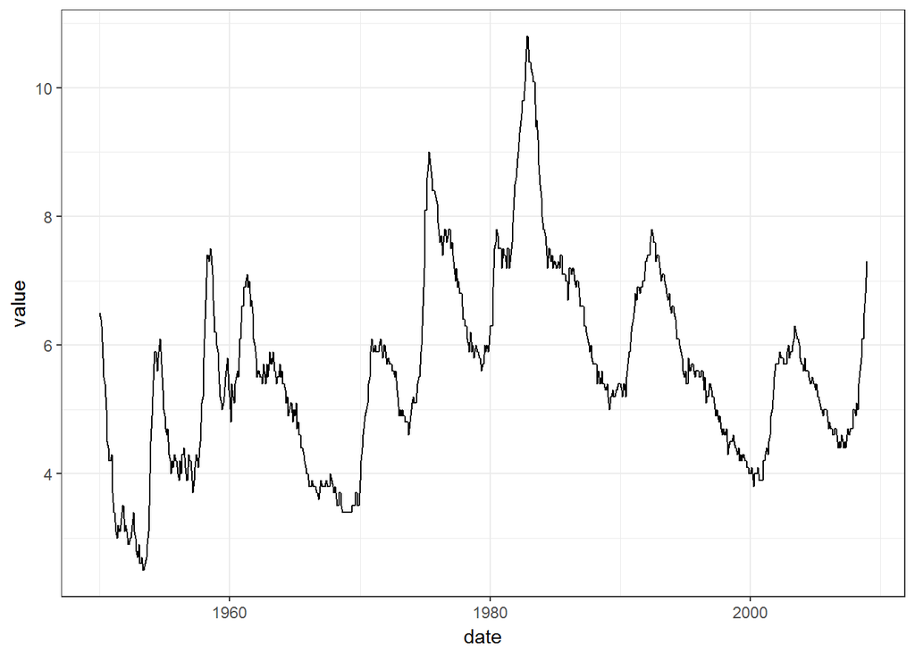

```r
Unemployment_rate <- read.xlsx2('data/SeriesReport-20170429073116_e1f8e3.xlsx',sheetIndex = 1,startRow = 12,endRow = 71,stringsAsFactors=FALSE)
Unemployment_rate <- data.frame(lapply(Unemployment_rate,as.numeric))
Unemployment_rate_melt <- Unemployment_rate %>% melt('Year')
plot_d <- transform(Unemployment_rate_melt,
                    date=strptime(paste(Unemployment_rate_melt[,1],Unemployment_rate_melt[,2],1,
                                        sep='-'),format="%Y-%b-%d"))
ggplot(plot_d,aes(x=date,y=value))+geom_line()
```

Industrial Productionのデータそのもののプロット  
論文中では2002年のデータを100にしていたが、現在は2012年基準になっている

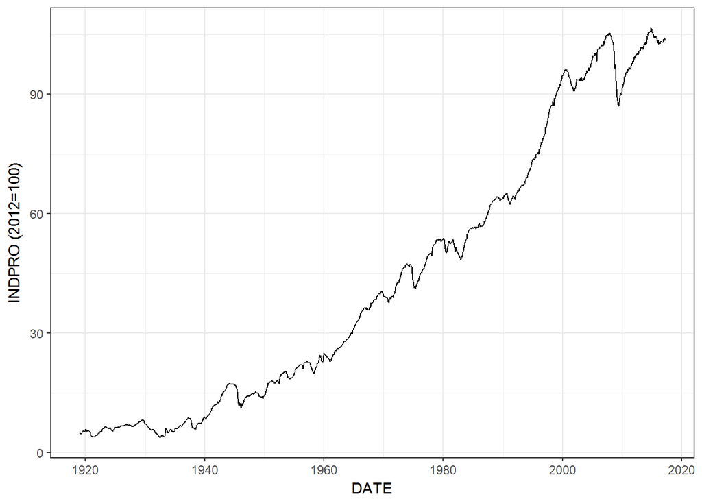

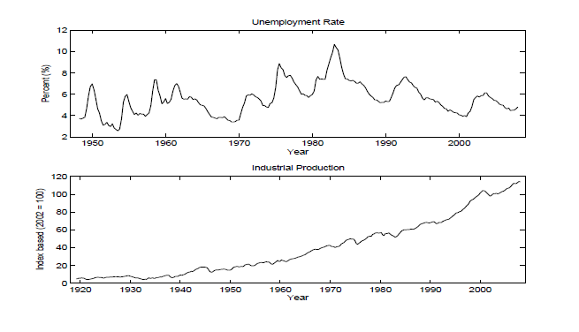

```r
INDPRO <- read.csv("data/INDPRO.csv",stringsAsFactors=FALSE)
INDPRO$DATE <- strptime(INDPRO$DATE,format="%Y-%m-%d")
ggplot(INDPRO,aes(x=DATE,y=INDPRO))+geom_line() + ylab("INDPRO (2012=100)")
```

Unemployment Rateのストレス因子  
annual percentage changeの具体的な計算方法が分からなかったのでそれっぽくしただけ  
雰囲気はつかめてるけど論文のものにくらべるとギザギザしている

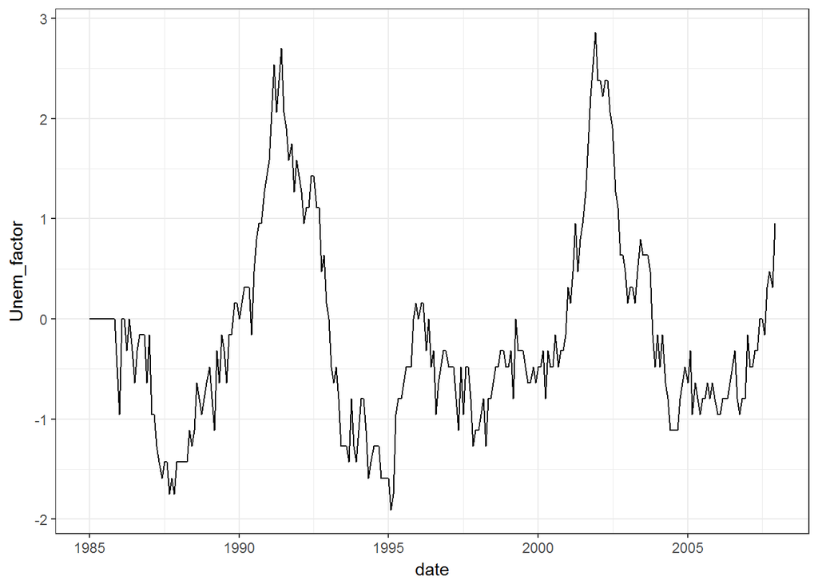

```r
Unemployment_rate_melt_dt <- plot_d[order(plot_d$date),]
Unem <- Unemployment_rate_melt_dt[Unemployment_rate_melt_dt$date>as.POSIXct('1984-12-31') & Unemployment_rate_melt_dt$date<as.POSIXct('2008-1-1'),]
Unem_diff<-c(0,diff(Unem$value))
Unem<-transform(Unem,Unem_diff = Unem_diff)
Unem_factor <- c()
for(i in 1:(length(Unem$Unem_diff)-11)){
  Unem_factor <- c(Unem_factor,sum(Unem$Unem_diff[i:(i+11)]))
}
Unem_factor <- c(rep(0,11),Unem_factor/sd(Unem_factor))
Unem <- transform(Unem,Unem_factor=Unem_factor)

ggplot(Unem,aes(x=date,y=Unem_factor))+geom_line()
```

Industrial Productionのストレス因子  
こちらもUnemploy Rateと同様の計算方法なので、論文のものよりギザギザしている

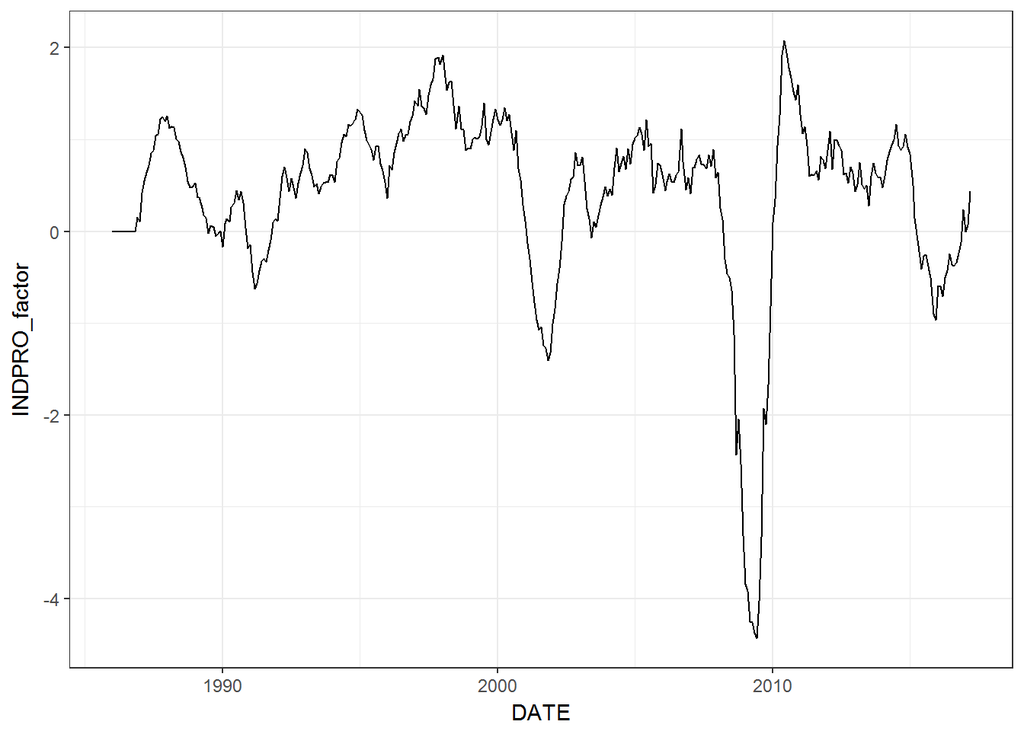

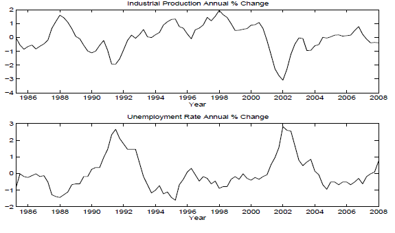

```r
INDPRO <- read.csv("data/INDPRO.csv",stringsAsFactors=FALSE)
INDPRO$DATE <- strptime(INDPRO$DATE,format="%Y-%m-%d")
INDPRO <- INDPRO[INDPRO$DATE > as.POSIXct('1985-12-30'),]
diff_INDPRO=c(0,diff(c(INDPRO$INDPRO)))
INDPRO <-transform(INDPRO,diff_INDPRO=diff_INDPRO)
INDPRO_factor <- c()
for(i in 1:(length(INDPRO$INDPRO)-11)){
  INDPRO_factor <- c(INDPRO_factor,sum(INDPRO$diff_INDPRO[i:(i+11)]))
}
INDPRO_factor <- c(rep(0,11),INDPRO_factor/sd(INDPRO_factor))
INDPRO <-transform(INDPRO,INDPRO_factor=INDPRO_factor)
ggplot(INDPRO,aes(x=DATE,y=INDPRO_factor))+geom_line()
```